# მონაცემთა მეცნიერება

##### მანქანური სწავლების გამოყენებამდე

### დუბლინის ხმაურის მონაცემები უბნების მიხედვით

საჯარო ინფორმაცია, გამოქვეყნებულია: https://data.smartdublin.ie/dataset/ambient-sound-monitoring-network

### რამდენიმე ბიბლიოთეკის ჩატვირთვა

ცნობარი ხმაურის ერთეულების შესახებ: http://www.acoustic-glossary.co.uk/leq.htm

```python
from __future__ import unicode_literals
```

```python
import pandas as pd
import numpy as np
import matplotlib
import matplotlib.pyplot as plt
matplotlib.style.use('ggplot')
```

```python
import glob
```

```python
%matplotlib notebook
```

ფაილებისა და ფოლდერების განლაგება

```python
%%bash
ls /home/revaz/data/public/dublin/raw/ballyfermot/2015/ | head
```

```
April 15
August 15
December 15
February 15
January 15
July 15
June 15
March 15
May 15
November 15
```

```python
%%bash
ls /home/revaz/data/public/dublin/raw/ballyfermot/2015/April\ 15/ | head
```

```
DCC-NOISE-001003-2015-04-01T00-00-00.txt
DCC-NOISE-001003-2015-04-02T00-00-00.txt
DCC-NOISE-001003-2015-04-03T00-00-00.txt
DCC-NOISE-001003-2015-04-04T00-00-00.txt
DCC-NOISE-001003-2015-04-05T00-00-00.txt
DCC-NOISE-001003-2015-04-07T09-15-00.txt
DCC-NOISE-001003-2015-04-08T00-00-00.txt
DCC-NOISE-001003-2015-04-09T00-00-00.txt
DCC-NOISE-001003-2015-04-10T00-00-00.txt
DCC-NOISE-001003-2015-04-11T00-00-00.txt
```

ფაილის ფორმატი: კომენტარი, გამყოფები, ინდექსი

```python
%%bash
head -n 15 '/home/revaz/data/public/dublin/raw/ballyfermot/2015/April 15/DCC-NOISE-001003-2015-04-08T00-00-00.txt'
```

```
# noise_analysis run from DCC-NOISE-001003 at Wed Apr  8 00:00:00 2015
# Monitoring unit located at 53.342609N 6.340721W
# logfile   = /home/root/noise_analysis.log
# cfg_dir   = /home/root/config
# outputdir = /home/root/noise
# Sensitivity = -26.271103
# Gain = 1.000000
# Time should be in local format (i.e. daylight savings time)
# dd/mm/yyyy hh:mm:ss, A Leq,   A L10,   A L95,   C Leq,   C L10,   C L95
08/04/2015 00:05:00,   49.71,   54.57,   44.29,   52.88,   57.02,   48.41
08/04/2015 00:10:00,   50.51,   55.63,   44.57,   52.99,   57.94,   48.05
08/04/2015 00:15:00,   49.48,   54.54,   44.70,   52.44,   56.76,   48.37
08/04/2015 00:20:00,   51.22,   56.75,   44.14,   53.85,   58.48,   48.34
08/04/2015 00:25:00,   50.34,   55.00,   43.98,   53.17,   56.99,   48.24
08/04/2015 00:30:00,   49.01,   54.69,   42.64,   52.28,   56.97,   47.26
```

ფაილის მისამართების სორტირებული სია

```python
# single district, one year time period
files = sorted(glob.glob('/home/revaz/data/public/dublin/raw/ballyfermot/2015/*/*.txt'))
```

```python
def get_header(file):
    """Get first 9 rows of each file as a list."""
    with open(files[0], 'r') as f:
        header = [f.readline() for _ in range(9)]

    return header
```

თანადობა თითოეული ფაილისა და მისი საწყისი კომენტარებისა

```python
headers = {file: get_header(file) for file in files} # dict comprehension
```

```python
# headers
```

```python
for i in range(9):
    unique_header_items = {v[i] for k, v in headers.items()} # set comprehension
    print(len(unique_header_items) == 1)
    # assert len(len(unique_header_items) == 1)
```

```
True
True
True
True
True
True
True
True
True
```

```python
len(files)
```

```
356
```

### ნედლი მონაცემების ჩატვირთვა

```python
all_dfs = [pd.read_csv(file, sep=',', index_col=0, parse_dates=True, dayfirst=True, skiprows=8)
           for file in files]
```

ერთი ფაილის ჩატვირთული ნიმუში

```python
all_dfs[130].head()
```

| # dd/mm/yyyy hh:mm:ss | A Leq | A L10 | A L95 | C Leq | C L10 | C L95 |
| --- | --- | --- | --- | --- | --- | --- |
| 2015-01-13 00:05:00 | 53.75 | 58.16 | 47.85 | 58.61 | 62.22 | 51.40 |
| 2015-01-13 00:10:00 | 51.10 | 55.54 | 46.01 | 55.79 | 59.15 | 50.28 |
| 2015-01-13 00:15:00 | 54.39 | 59.99 | 46.47 | 57.83 | 62.21 | 50.61 |
| 2015-01-13 00:20:00 | 54.16 | 58.18 | 48.50 | 57.35 | 59.92 | 51.74 |
| 2015-01-13 00:25:00 | 53.27 | 58.28 | 45.04 | 55.61 | 59.76 | 48.90 |

ფაილების გაერთიანება (კონკატენაცია)

```python
full_df = pd.concat(all_dfs)
```

```python
full_df.head()
```

| # dd/mm/yyyy hh:mm:ss | A Leq | A L10 | A L95 | C Leq | C L10 | C L95 |
| --- | --- | --- | --- | --- | --- | --- |
| 2015-04-01 00:05:00 | 52.67 | 56.38 | 48.27 | 57.99 | 61.66 | 52.73 |
| 2015-04-01 00:10:00 | 53.07 | 56.38 | 48.31 | 58.47 | 62.39 | 52.76 |
| 2015-04-01 00:15:00 | 52.26 | 56.27 | 47.72 | 58.48 | 62.80 | 52.33 |
| 2015-04-01 00:20:00 | 54.60 | 58.68 | 49.95 | 59.00 | 62.77 | 54.17 |
| 2015-04-01 00:25:00 | 51.65 | 55.98 | 47.13 | 57.43 | 60.42 | 52.04 |

საჭიროა ინდექსის სორტირება

```python
full_df.sort_index(inplace=True)
```

ინდექსისა და სვეტების სახელების გადარქმევა

```python
full_df.columns
```

```
Index([' A Leq', '   A L10', '   A L95', '   C Leq', '   C L10', '   C L95'], dtype='object')
```

```python
full_df.index.name = 'timestamp'
```

```python
full_df.rename(columns=lambda name: name.strip(), inplace=True)
```

### რაოდენობრივი ანალიზი

გამოტოვებული დროითი ინტერვალები

```python
time_index = full_df.index.to_series()
```

```python
time_diff = time_index - time_index.shift(1)
```

```python
sorted(list(set(time_diff.dropna())))
```

```
[Timedelta('0 days 00:05:00'),
 Timedelta('0 days 00:08:00'),
 Timedelta('0 days 00:10:00'),
 Timedelta('0 days 00:15:00'),
 Timedelta('0 days 00:35:00'),
 Timedelta('0 days 00:52:00'),
 Timedelta('0 days 01:05:00'),
 Timedelta('0 days 01:35:00'),
 Timedelta('0 days 05:50:00'),
 Timedelta('0 days 15:45:00'),
 Timedelta('1 days 16:05:00'),
 Timedelta('2 days 00:35:00'),
 Timedelta('10 days 03:00:00')]
```

```python
time_diff.value_counts(dropna=False).sort_index()
```

```
0 days 00:05:00     100128
0 days 00:08:00          1
0 days 00:10:00        345
0 days 00:15:00          1
0 days 00:35:00          2
0 days 00:52:00          1
0 days 01:05:00          1
0 days 01:35:00          1
0 days 05:50:00          1
0 days 15:45:00          1
1 days 16:05:00          1
2 days 00:35:00          1
10 days 03:00:00         1
NaT                      1
Name: timestamp, dtype: int64
```

```python
time_diff[time_diff > pd.Timedelta(minutes=10)]
```

```
timestamp
2015-03-29 02:00:00    0 days 01:05:00
2015-04-07 09:20:00    2 days 00:35:00
2015-04-23 00:05:00    1 days 16:05:00
2015-05-06 00:42:00    0 days 00:52:00
2015-05-12 08:45:00    0 days 00:15:00
2015-06-08 07:35:00    0 days 05:50:00
2015-07-17 11:45:00    0 days 15:45:00
2015-08-19 00:05:00    0 days 00:35:00
2015-08-26 00:05:00    0 days 01:35:00
2015-09-02 00:05:00    0 days 00:35:00
2015-11-02 12:00:00   10 days 03:00:00
Name: timestamp, dtype: timedelta64[ns]
```

### რაოდენობა, საზღვრები, მარტივი სტატისტიკა

```python
full_df.describe()
```

|  | A Leq | A L10 | A L95 | C Leq | C L10 | C L95 |
| --- | --- | --- | --- | --- | --- | --- |
| count | 100486.000000 | 100486.000000 | 100486.000000 | 100486.000000 | 100486.000000 | 100486.000000 |
| mean | 55.438619 | 58.942623 | 50.003629 | 58.964681 | 62.382394 | 53.738554 |
| std | 4.316676 | 3.735171 | 5.151423 | 4.684690 | 4.424431 | 5.079923 |
| min | 33.380000 | 34.660000 | 30.180000 | 39.210000 | 40.560000 | 34.270000 |
| 25% | 53.160000 | 57.140000 | 46.890000 | 56.240000 | 60.070000 | 50.460000 |
| 50% | 55.870000 | 59.180000 | 50.470000 | 59.700000 | 62.780000 | 54.520000 |
| 75% | 58.430000 | 61.350000 | 53.850000 | 61.990000 | 64.840000 | 57.490000 |
| max | 78.470000 | 84.660000 | 67.230000 | 81.350000 | 88.650000 | 71.730000 |

დამატებით 1-ლი და 99-ე მეასედების შემოწმება

```python
full_df.describe([0.01, 0.25, 0.5, 0.75, 0.99])
```

|  | A Leq | A L10 | A L95 | C Leq | C L10 | C L95 |
| --- | --- | --- | --- | --- | --- | --- |
| count | 100486.000000 | 100486.000000 | 100486.000000 | 100486.000000 | 100486.000000 | 100486.000000 |
| mean | 55.438619 | 58.942623 | 50.003629 | 58.964681 | 62.382394 | 53.738554 |
| std | 4.316676 | 3.735171 | 5.151423 | 4.684690 | 4.424431 | 5.079923 |
| min | 33.380000 | 34.660000 | 30.180000 | 39.210000 | 40.560000 | 34.270000 |
| 1% | 43.620000 | 47.970000 | 36.490000 | 46.820000 | 50.860000 | 40.600000 |
| 25% | 53.160000 | 57.140000 | 46.890000 | 56.240000 | 60.070000 | 50.460000 |
| 50% | 55.870000 | 59.180000 | 50.470000 | 59.700000 | 62.780000 | 54.520000 |
| 75% | 58.430000 | 61.350000 | 53.850000 | 61.990000 | 64.840000 | 57.490000 |
| 99% | 64.021500 | 67.010000 | 59.470000 | 70.010000 | 75.321500 | 62.760000 |
| max | 78.470000 | 84.660000 | 67.230000 | 81.350000 | 88.650000 | 71.730000 |

საშუალოსა და მედიანას შორის აბსოლუტური სხვაობა

```python
abs(full_df.describe().loc['mean'] - full_df.describe().loc['50%'])
```

```
A Leq    0.431381
A L10    0.237377
A L95    0.466371
C Leq    0.735319
C L10    0.397606
C L95    0.781446
dtype: float64
```

დისკრეტული დიფერენციალის სტატისტიკა

```python
diff_df = full_df.diff()
```

```python
diff_df.describe([0.01, 0.25, 0.5, 0.75, 0.99])
```

|  | A Leq | A L10 | A L95 | C Leq | C L10 | C L95 |
| --- | --- | --- | --- | --- | --- | --- |
| count | 100485.000000 | 100485.000000 | 100485.000000 | 100485.000000 | 100485.000000 | 100485.000000 |
| mean | -0.000017 | -0.000012 | -0.000024 | -0.000013 | -0.000012 | -0.000020 |
| std | 1.466235 | 1.813815 | 1.343201 | 1.607435 | 2.141717 | 1.293421 |
| min | -16.280000 | -24.200000 | -14.180000 | -15.620000 | -20.900000 | -14.620000 |
| 1% | -3.951600 | -5.210000 | -3.370000 | -4.180000 | -5.760000 | -3.240000 |
| 25% | -0.760000 | -0.830000 | -0.800000 | -0.900000 | -1.120000 | -0.770000 |
| 50% | -0.010000 | -0.010000 | 0.000000 | -0.010000 | -0.020000 | 0.010000 |
| 75% | 0.760000 | 0.820000 | 0.800000 | 0.890000 | 1.090000 | 0.780000 |
| 99% | 4.000000 | 5.340000 | 3.320000 | 4.230000 | 5.850000 | 3.200000 |
| max | 18.090000 | 23.190000 | 16.650000 | 16.870000 | 21.580000 | 17.800000 |

### ვიზუალიზაცია

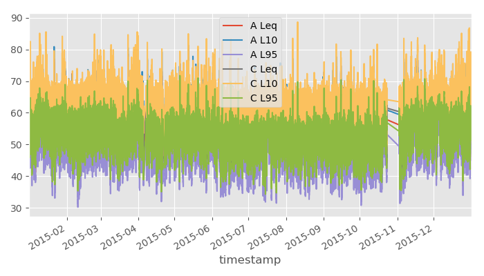

```python
f, ax = plt.subplots(figsize=(7, 4))

full_df.plot(ax=ax)

plt.tight_layout()
plt.show()
```

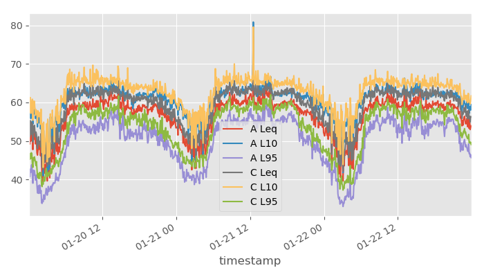

```python
f, ax = plt.subplots(figsize=(7, 4))

full_df['2015-01-20':'2015-01-22'].plot(ax=ax)

plt.tight_layout()
plt.show()
```

დღიური მაქსიმუმები

```python
daily_max = full_df.groupby(pd.Grouper(freq='1D')).max()
```

```python
daily_max_for_heatmap = daily_max.copy()

daily_max_for_heatmap.index = daily_max_for_heatmap.index.date
```

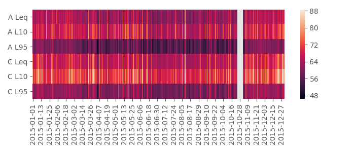

```python
import seaborn as sns
f, ax = plt.subplots(1, 1, figsize=(7, 3))
sns.heatmap(daily_max_for_heatmap.T, ax=ax)

for tick in ax.get_yticklabels():
    tick.set_rotation(0)
for tick in ax.get_xticklabels():
    tick.set_rotation(90)
plt.tight_layout()
plt.show()
```

#### ყოველთვიური საშუალო მაჩვენებლები

```python
monthly_means = full_df.groupby(pd.Grouper(freq='MS')).mean()
```

```python
monthly_means.index = monthly_means.index.date
```

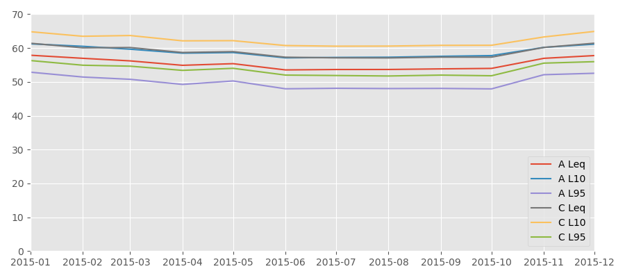

```python
f, ax = plt.subplots(1, 1, figsize=(9, 4))

monthly_means.plot(ax=ax)
ax.set_ylim(0, 70)
plt.legend(loc=4)
plt.tight_layout()
plt.show()
```

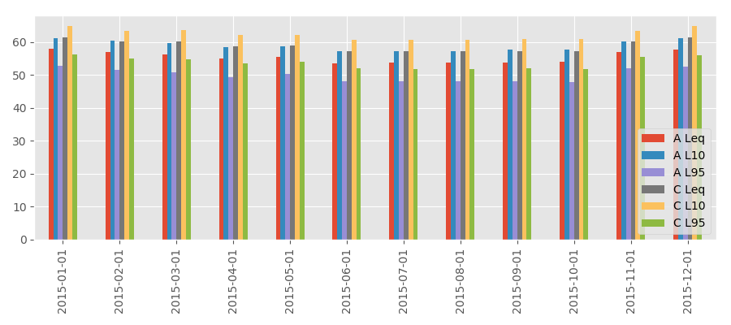

```python
f, ax = plt.subplots(1, 1, figsize=(9, 4))

monthly_means.plot.bar(ax=ax)
plt.legend(loc=4)
plt.tight_layout()
plt.show()
```

#### სიმჭიდროვის ვიზუალიზაცია

მონაცემების დღეებად დაყოფა და ზედდება

```python
daily_ALEQ = [group for group in full_df['A Leq'].groupby(pd.Grouper(freq='1D'))]
# full_df.columns
```

```python
for date, series in daily_ALEQ:
    series.name = date.date()
    series.index = series.index.time
```

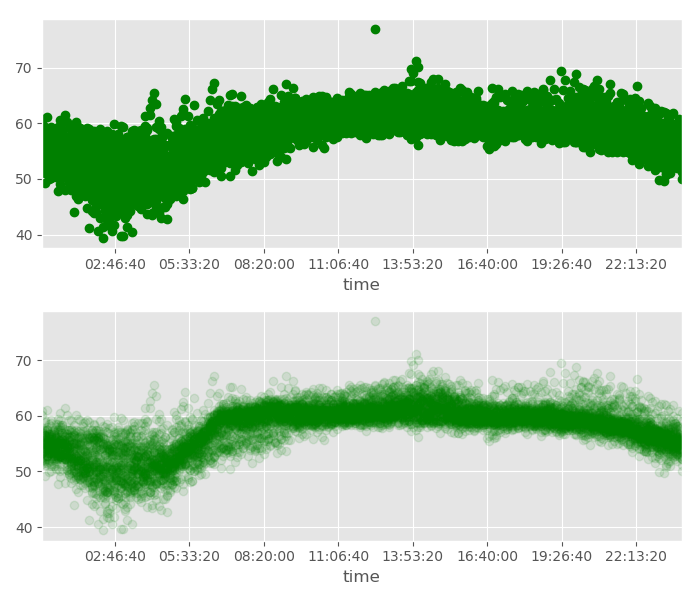

```python
f, ax = plt.subplots(2, 1, figsize=(7, 6))

for date, series in daily_ALEQ[:30]:
    if series.empty:
        continue
    series.plot(ax=ax[0], marker='o', lw=0, c='g')
    series.plot(ax=ax[1], marker='o', lw=0, c='g', alpha=0.1)

#     ax.legend()

plt.tight_layout()
plt.show()
```

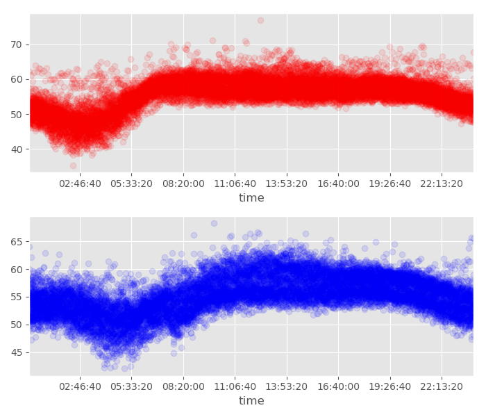

```python
f, ax = plt.subplots(2, 1, figsize=(7, 6))

for date, series in daily_ALEQ:
    if series.empty:
        continue

    if date.dayofweek == 2:
        series.plot(ax=ax[0], marker='o', alpha=0.1, lw=0, c='r')
    if date.dayofweek == 6:
        series.plot(ax=ax[1], marker='o', alpha=0.1, lw=0, c='b')
#     ax.legend()

plt.tight_layout()
plt.show()
```

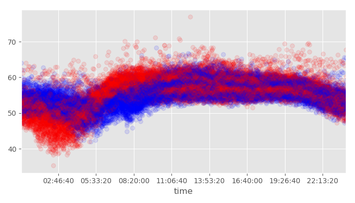

```python
f, ax = plt.subplots(1, 1, figsize=(7, 4))

for date, series in daily_ALEQ:
    if series.empty:
        continue

    if date.dayofweek == 2:
        series.plot(ax=ax, marker='o', alpha=0.1, lw=0, c='r')
    if date.dayofweek == 6:
        series.plot(ax=ax, marker='o', alpha=0.1, lw=0, c='b')
#     ax.legend()

plt.tight_layout()
plt.show()
```

#### საათობრივი განაწილება

```python
hourly_ALEQ = [group for group in full_df['A Leq'].groupby(pd.Grouper(freq='1H'))]
```

```python
group, series = hourly_ALEQ[0]
```

```python
hourly_ticks = pd.date_range(start='00:00:00', end='23:59:59', freq='1H').time
```

```python
def cut_hour(hourly_grouped, time):
    return pd.concat(
        [series
         for group, series in hourly_grouped
         if group.time() == time]
    )

hourly_series_dict = {str(time): cut_hour(hourly_ALEQ, time) for time in hourly_ticks}
```

ამონარიდი ბოქს-გრაფიკის დოკუმენტაციიდან:

whis : float, sequence, or string (default = 1.5)

```
As a float, determines the reach of the whiskers to the beyond the first and third quartiles. In other words, where IQR is the interquartile range (Q3-Q1), the upper whisker will extend to last datum less than Q3 + whis*IQR). Similarly, the lower whisker will extend to the first datum greater than Q1 - whis*IQR. Beyond the whiskers, data are considered outliers and are plotted as individual points. Set this to an unreasonably high value to force the whiskers to show the min and max values. Alternatively, set this to an ascending sequence of percentile (e.g., [5, 95]) to set the whiskers at specific percentiles of the data. Finally, whis can be the string 'range' to force the whiskers to the min and max of the data.
```

```python
# hourly_series_dict['00:00:00'].reset_index(drop=True)
```

```python
noindex_hourly_dict = {time: series.reset_index(drop=True) for time, series in hourly_series_dict.items()}
```

```python
noindex_hourly_df = pd.DataFrame(noindex_hourly_dict)
```

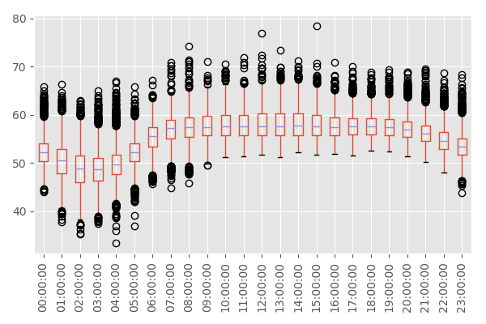

```python
f, ax = plt.subplots(figsize=(6, 4))

noindex_hourly_df.plot.box(ax=ax)
for tick in ax.get_xticklabels():
    tick.set_rotation(90)

plt.tight_layout()
plt.show()
```

### გამონაკლისები როგორც მნიშვნელოვანი სიდიდეები

```python
p999 = diff_df.describe([0.999]).loc['99.9%']
```

```python
p999
```

```
A Leq     7.42032
A L10    10.47160
A L95     5.82516
C Leq     7.39644
C L10    10.41128
C L95     5.37516
Name: 99.9%, dtype: float64
```

```python
significants = {col:full_df[diff_df[col] > p999[col]][col]
                for col in diff_df}
```

```python
significants_df = pd.DataFrame(significants, columns=full_df.columns)
```

```python
significants_df
```

| timestamp | A Leq | A L10 | A L95 | C Leq | C L10 | C L95 |
| --- | --- | --- | --- | --- | --- | --- |
| 2015-01-04 10:35:00 | NaN | NaN | NaN | NaN | 76.04 | NaN |
| 2015-01-05 01:35:00 | NaN | NaN | 48.42 | NaN | NaN | 50.55 |
| 2015-01-06 03:10:00 | 56.86 | 62.93 | NaN | 66.61 | 74.34 | NaN |
| 2015-01-07 02:35:00 | NaN | NaN | NaN | NaN | 68.37 | NaN |
| 2015-01-13 15:55:00 | NaN | NaN | 62.40 | NaN | NaN | NaN |
| 2015-01-19 02:05:00 | NaN | 56.93 | NaN | NaN | NaN | NaN |
| 2015-01-20 02:25:00 | NaN | 52.77 | NaN | NaN | 54.90 | NaN |
| 2015-01-20 03:05:00 | NaN | 55.37 | NaN | NaN | 55.68 | NaN |
| 2015-01-20 03:30:00 | NaN | 56.25 | NaN | NaN | 57.04 | NaN |
| 2015-01-21 04:25:00 | 53.29 | 58.82 | NaN | NaN | NaN | NaN |
| 2015-01-21 12:30:00 | 76.96 | 80.85 | NaN | 75.95 | 79.56 | NaN |
| 2015-01-22 02:45:00 | 49.29 | 58.32 | NaN | 50.94 | 59.31 | NaN |
| 2015-01-22 03:10:00 | NaN | 53.53 | NaN | NaN | 55.03 | NaN |
| 2015-01-22 04:15:00 | 51.05 | NaN | NaN | 55.20 | NaN | NaN |
| 2015-01-22 12:45:00 | NaN | NaN | NaN | NaN | NaN | 58.79 |
| 2015-01-26 01:45:00 | NaN | NaN | NaN | 60.97 | 68.18 | NaN |
| 2015-01-28 04:05:00 | NaN | NaN | NaN | 71.66 | NaN | 59.59 |
| 2015-01-29 15:45:00 | NaN | 73.41 | NaN | NaN | NaN | NaN |
| 2015-01-30 13:50:00 | 69.83 | NaN | NaN | 72.36 | NaN | NaN |
| 2015-01-30 14:50:00 | NaN | NaN | 62.99 | NaN | NaN | NaN |
| 2015-02-05 12:10:00 | 72.39 | NaN | NaN | 72.14 | NaN | NaN |
| 2015-02-07 15:40:00 | NaN | NaN | 60.37 | NaN | NaN | NaN |
| 2015-02-09 11:40:00 | NaN | 73.47 | NaN | NaN | NaN | NaN |
| 2015-02-09 20:15:00 | NaN | NaN | NaN | NaN | NaN | 54.03 |
| 2015-02-10 00:15:00 | NaN | NaN | 42.47 | NaN | NaN | NaN |
| 2015-02-10 02:05:00 | NaN | 49.52 | NaN | NaN | NaN | NaN |
| 2015-02-10 02:35:00 | NaN | NaN | NaN | NaN | 57.37 | NaN |
| 2015-02-10 04:15:00 | 48.00 | 54.87 | NaN | 49.94 | 56.38 | NaN |
| 2015-02-11 04:15:00 | NaN | 54.28 | NaN | NaN | NaN | NaN |
| 2015-02-12 10:35:00 | NaN | NaN | 63.43 | NaN | NaN | 65.01 |
| ... | ... | ... | ... | ... | ... | ... |
| 2015-11-18 04:15:00 | NaN | NaN | NaN | 61.24 | NaN | NaN |
| 2015-11-23 12:25:00 | NaN | NaN | 64.01 | NaN | NaN | 67.58 |
| 2015-11-23 14:40:00 | NaN | NaN | NaN | 74.99 | NaN | NaN |
| 2015-12-03 02:10:00 | NaN | NaN | NaN | NaN | 67.37 | NaN |
| 2015-12-04 08:45:00 | 67.41 | 73.43 | NaN | NaN | NaN | NaN |
| 2015-12-08 03:50:00 | 56.67 | 63.39 | NaN | 65.86 | 73.36 | NaN |
| 2015-12-13 11:50:00 | NaN | NaN | 57.85 | NaN | NaN | NaN |
| 2015-12-14 03:30:00 | 52.53 | 59.44 | NaN | 57.75 | 64.53 | NaN |
| 2015-12-14 04:00:00 | 49.12 | 55.53 | NaN | NaN | NaN | NaN |
| 2015-12-16 09:55:00 | 71.12 | NaN | NaN | 71.08 | NaN | NaN |
| 2015-12-16 20:25:00 | 66.98 | 75.32 | NaN | NaN | NaN | NaN |
| 2015-12-18 02:20:00 | NaN | NaN | 53.94 | NaN | NaN | NaN |
| 2015-12-18 04:30:00 | NaN | NaN | 54.25 | NaN | NaN | 54.58 |
| 2015-12-18 05:50:00 | NaN | NaN | 54.97 | NaN | NaN | NaN |
| 2015-12-18 06:35:00 | NaN | NaN | 55.10 | NaN | NaN | NaN |
| 2015-12-23 01:50:00 | NaN | NaN | 56.51 | NaN | NaN | 59.06 |
| 2015-12-23 02:20:00 | NaN | NaN | 56.52 | NaN | NaN | 56.96 |
| 2015-12-23 04:45:00 | NaN | NaN | NaN | NaN | NaN | 57.68 |
| 2015-12-23 05:10:00 | NaN | NaN | 54.84 | NaN | NaN | NaN |
| 2015-12-23 21:05:00 | NaN | NaN | 65.31 | NaN | NaN | NaN |
| 2015-12-25 05:30:00 | 58.29 | 66.04 | NaN | 63.07 | 72.32 | NaN |
| 2015-12-25 07:05:00 | 64.42 | 75.25 | NaN | 66.55 | 77.12 | NaN |
| 2015-12-25 07:45:00 | 61.05 | NaN | NaN | NaN | NaN | NaN |
| 2015-12-25 08:10:00 | 65.10 | 71.79 | NaN | 65.86 | 72.22 | NaN |
| 2015-12-25 09:50:00 | NaN | NaN | NaN | 64.04 | NaN | NaN |
| 2015-12-25 14:05:00 | NaN | NaN | 58.91 | NaN | NaN | NaN |
| 2015-12-26 18:45:00 | 68.84 | 75.48 | NaN | 69.60 | 75.68 | NaN |
| 2015-12-28 03:55:00 | NaN | NaN | NaN | 62.90 | NaN | NaN |
| 2015-12-31 09:30:00 | NaN | NaN | NaN | 70.01 | 76.70 | NaN |
| 2015-12-31 16:55:00 | NaN | 75.22 | NaN | NaN | 79.20 | NaN |

301 rows × 6 columns

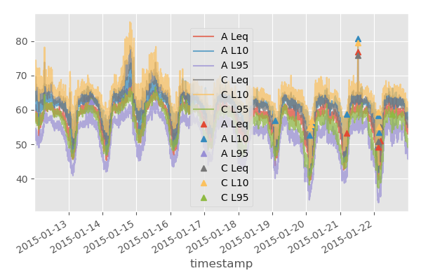

```python
f, ax = plt.subplots(figsize=(6, 4))

full_df['2015-01-12':'2015-01-22'].plot(alpha=0.7, ax=ax)
plt.gca().set_prop_cycle(None)
significants_df['2015-01-12':'2015-01-22'].plot(marker='^', lw=0, ax=ax)

plt.tight_layout()
plt.show()
```

#### დაგლუვება

```python
smooth_df = full_df.rolling(window=36).mean()
```

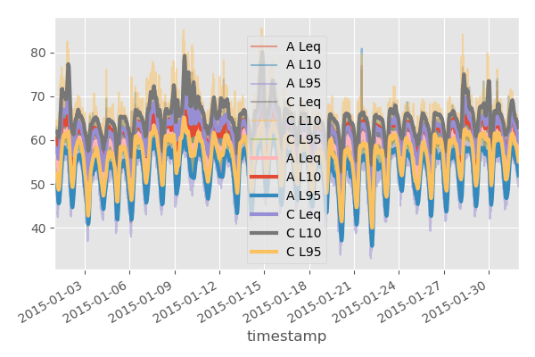

```python
f, ax = plt.subplots(1, 1, figsize=(6, 4))

full_df['2015-01-01':'2015-01-31'].plot(ax=ax, alpha=0.5)
smooth_df['2015-01-01':'2015-01-31'].plot(ax=ax, lw=3.0)

plt.tight_layout()
plt.show()
```

### კორელაციები

კორელაციის მატრიცა სრულ დროზე

```python
full_df.corr()
```

|  | A Leq | A L10 | A L95 | C Leq | C L10 | C L95 |
| --- | --- | --- | --- | --- | --- | --- |
| A Leq | 1.000000 | 0.970561 | 0.947658 | 0.959533 | 0.912897 | 0.934417 |
| A L10 | 0.970561 | 1.000000 | 0.869528 | 0.922507 | 0.917344 | 0.853089 |
| A L95 | 0.947658 | 0.869528 | 1.000000 | 0.919187 | 0.835545 | 0.981759 |
| C Leq | 0.959533 | 0.922507 | 0.919187 | 1.000000 | 0.973314 | 0.943010 |
| C L10 | 0.912897 | 0.917344 | 0.835545 | 0.973314 | 1.000000 | 0.861261 |
| C L95 | 0.934417 | 0.853089 | 0.981759 | 0.943010 | 0.861261 | 1.000000 |

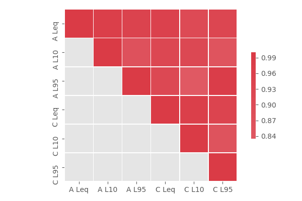

```python
f, ax = plt.subplots(1, 1, figsize=(6, 4))

cmap = sns.diverging_palette(100, 10, as_cmap=True)
mask = np.ones_like(full_df.corr(), dtype=np.bool)
mask[np.triu_indices_from(mask)] = 0
# centered
sns.heatmap(full_df.corr(), center=0, square=True, cmap=cmap, mask=mask, linewidths=.5, cbar_kws={"shrink": .5})
# not centered
# sns.heatmap(full_df.corr(), square=True, cmap=cmap, mask=mask, linewidths=.5, cbar_kws={"shrink": .5})

plt.tight_layout()
plt.show()
```

დღიური კორელაცია

```python
daily_ALL = [group for group in full_df.groupby(pd.Grouper(freq='1D'))]
```

```python
corr_by_date = {date: daily_df.corr() for date, daily_df in daily_ALL}
```

```python
one_to_all_corr = {date: corr['A L95'] for date, corr in corr_by_date.items()}
```

```python
one_to_all_corr_df = pd.DataFrame(one_to_all_corr).T
```

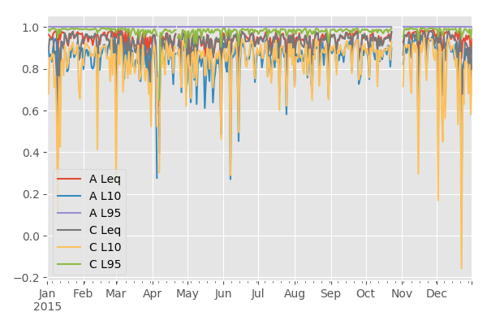

```python
f, ax = plt.subplots(figsize=(6, 4))

one_to_all_corr_df.plot(ax=ax)

plt.tight_layout()
plt.show()
```

# შეჯამება

### შეგროვებულ მონაცემებში ნაპოვნი ხარვეზები:

- მონაცემთა ჩაწერის სიხშირე არაა სტაბილურად 5 წუთი
- მონაცემებს ჩაწერისას მუდმივად გამოტოვებულია შუაღამის მონაცემები
- ჩანაწერთა უმრავლესობა დამრგვალებულია 5 წუთზე, მაგრამ არა ყველა
- არის რამდენიმე ჩავარდნა, რომელიც 1 დღეზე მეტია. კვირების, თვეების და ა.შ. ქვეჯგუფების აჯამვისას შესაძლოა გამოიწვიოს უზუსტობა, რომელიც არ ექვემბდებარება გადამოწმებას
- სიჩუმეში ხმაურის სტატისტიკური ხმაური მეტია, ამიტომ დღისა და ღამის ანალიზი ზოგიერთი ამოცანისთვის ერთმანეთისგან განცალკევებით სჯობს

### ანალიზის შესაძლო განვითარება

### მანქანური სწავლებისთვის მომზადება

- მუდმივ სიდიდეთა სტატისტიკური ნორმალიზაცია
- კატეგორიათა ბინარიზაცია
- სტატისტიკური გამონაკლისების მოშორება
- მონაცემთა კრებულის საწვრთნელ და შესამოწმებელ ნაწილად დაყოფა (Training and Test data sets)